# Data Visualization Analysis

Author

Daven

Published

December 20, 2024

## 1 Introduction

This tutorial is designed to help you learn data visualization analysis by providing simple and useful information in a way that is easy to follow and understand.

## 2 Preparation

In order to draw a chart, we need to include the required packages for visualization and dataset. For example, `ggplot2` package is for drawing charts and `gcookbook` is for using `pg_mean` dataset.

```r
library(ggplot2)
library(gcookbook)
```

## 3 Bar chart

In this section, we will draw a bar chart using `pg_mean` dataset. The dataset has two columns: `group`, `weight`.

```r
pg_mean
```

```
  group weight
1  ctrl  5.032
2  trt1  4.661
3  trt2  5.526
```

This dataset compares the weight across three groups:

- `ctrl`: Control group (baseline, weight = 5.032).
- `trt1`: Treatment 1 group (weight = 4.661).
- `trt2`: Treatment 2 group (weight = 5.526).

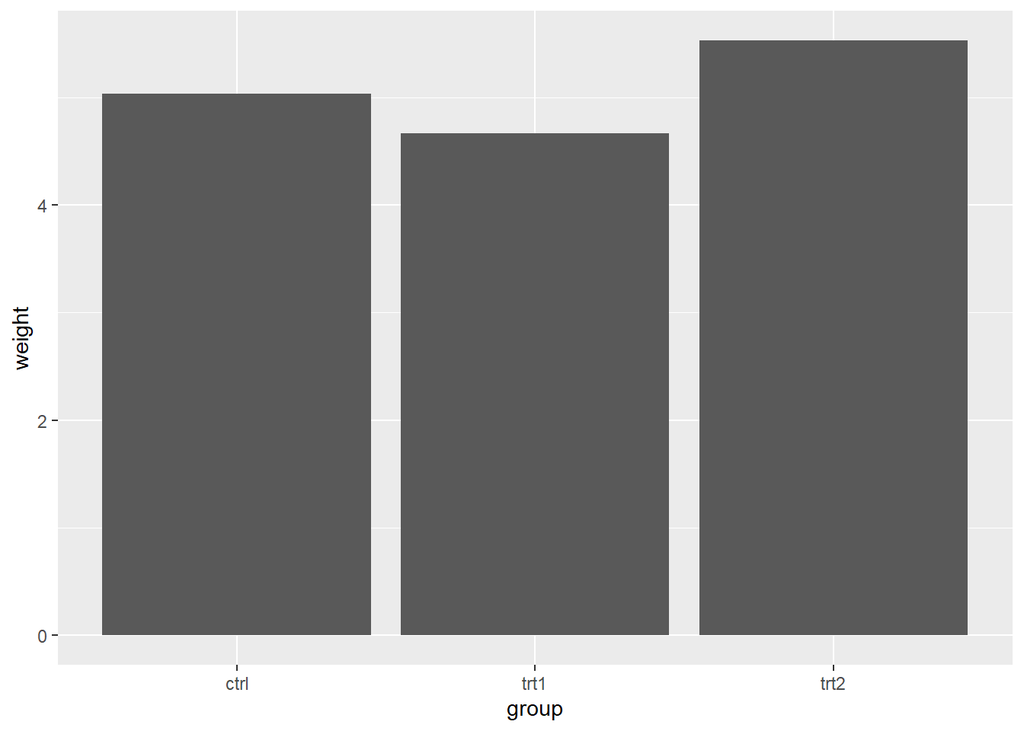

```r
ggplot(pg_mean, aes(x = group, y = weight)) +
  geom_col()
```

It initializes a ggplot with the dataset `pg_mean`.

`aes(x = group, y = weight)` specifies the aesthetics:

- `x = group`: Assign the `group` variable to the x-axis (categorical data, such as `ctrl, trt1, trt2`).
- `y = weight`: Assign the `weight` variable to the y-axis (numerical data).

`geom_col()`:

- Adds a column geometry to the plot.
- `geom_col()` creates bars where the height of each bar corresponds to the value of weight for each group.

## 4 Bar chart with color

We can expand further our bar chart by adding colors to its shape and outline to add more visualization into it. However, first we need to include `gcookbook` for using `pg_mean` dataset and `ggplot2` for drawing the chart.

```r
library(gcookbook)
library(ggplot2)
```

Here we need to initializes `pg_mean` dataset by using `gcookbook` library within our code.

```r
pg_mean
```

```
  group weight
1  ctrl  5.032
2  trt1  4.661
3  trt2  5.526
```

A quick preview of `pg_mean` dataset.

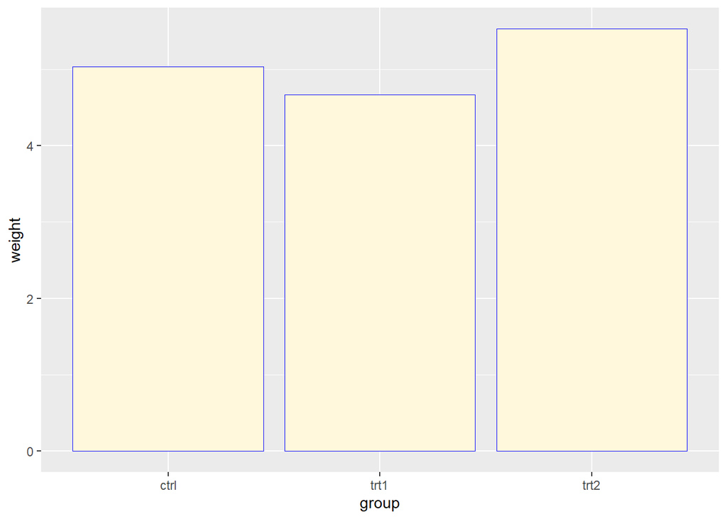

```r
ggplot(pg_mean, aes(x = group, y = weight)) +
  geom_col(fill = 'cornsilk', colour = 'blue', size = .2)
```

As we demonstrate before at Bar chart, `aes(x = group, y = weight)` specifies the aesthetics:

- `x = group`: Assign the `group` variable to the x-axis (categorical data, such as `ctrl, trt1, trt2`).
- `y = weight`: Assign the `weight` variable to the y-axis (numerical data).

`geom_col()`:

- Adds a column geometry to the plot.
- `geom_col()` creates bars where the height of each bar corresponds to the value of weight for each group.

Inside `geom_col()` command, `fill = "cornsilk", colour = "blue", size = .2` specifies the following:

- `fill = "cornsilk"`: Assign color to the bar’s area using the color `"cornsilk"`.
- `colour = "blue"`: Assign color to the bar’s outline using the color `"blue"`.
- `size = .2`: Specified the size of the outline for all the bar within the chart.

```r
labs(title = 'Bar Chart w/ Color',
       caption = 'By Daven, DV, THU, 2024') +
  theme(plot.title = element_text(hjust = 0.5, size = 20))
```

To add more details on your chart, we can add `labs()` and `theme()` into our codes.

`labs()`:

- Used to customized axis labels and legend titles.
- To add `title` and `caption` unto the chart.

`theme()`:

- Used to give plots a consistent customized look.
- Positioning your chart `title` and adjusting the `size` of your chart font

```r
labs(title = 'Bar Chart w/ Color',
       caption = 'By Daven, DV, THU, 2024')
```

```r
theme(plot.title = element_text(hjust = 0.5, size = 20))
```

Inside `theme()`:

- `plot.title = element_text()`: To customize the `title` chart to your desire output.

Inside `plot.title = element_text()`:

- `hjust = 0.5`: Positioning your chart `title` in the middle.
- `size = 20`: Sizing your title text to `size` 20.

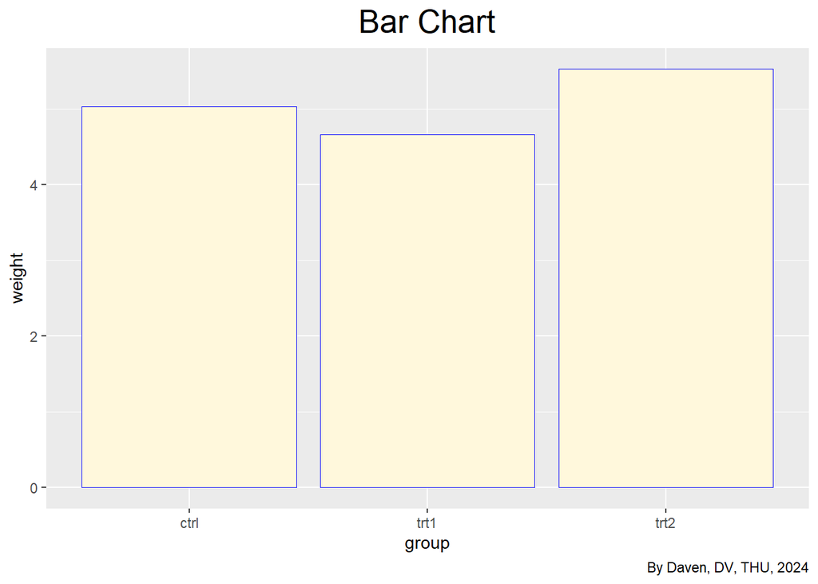

```r
library(gcookbook)
library(ggplot2)

ggplot(pg_mean, aes(x = group, y = weight)) +
  geom_col(fill = 'cornsilk', colour = 'blue', size = .2) +
  labs(title = 'Bar Chart',
       caption = 'By Daven, DV, THU, 2024') +
  theme(plot.title = element_text(hjust = 0.5, size = 20))
```

For a better view of the overall explanation above, this is the complete structure on how the codes *given above* should be arranged.

*Note: You can use different colors on chart’s area and outline like `'red'` or `'green'` as well as the size of your chart title and positioning `(hjust = 1, size = 15)`.*

## 5 Line chart

Using the same Preparation, we’ll be using the same library which is `gcookbook` and `ggplot2` library.

```r
library(gcookbook)
library(ggplot2)
```

Here we need to initializes `BOD` dataset by using `gcookbook()` library within our code.

```r
BOD
```

```
  Time demand
1    1    8.3
2    2   10.3
3    3   19.0
4    4   16.0
5    5   15.6
6    7   19.8
```

A quick preview of `BOD` dataset.

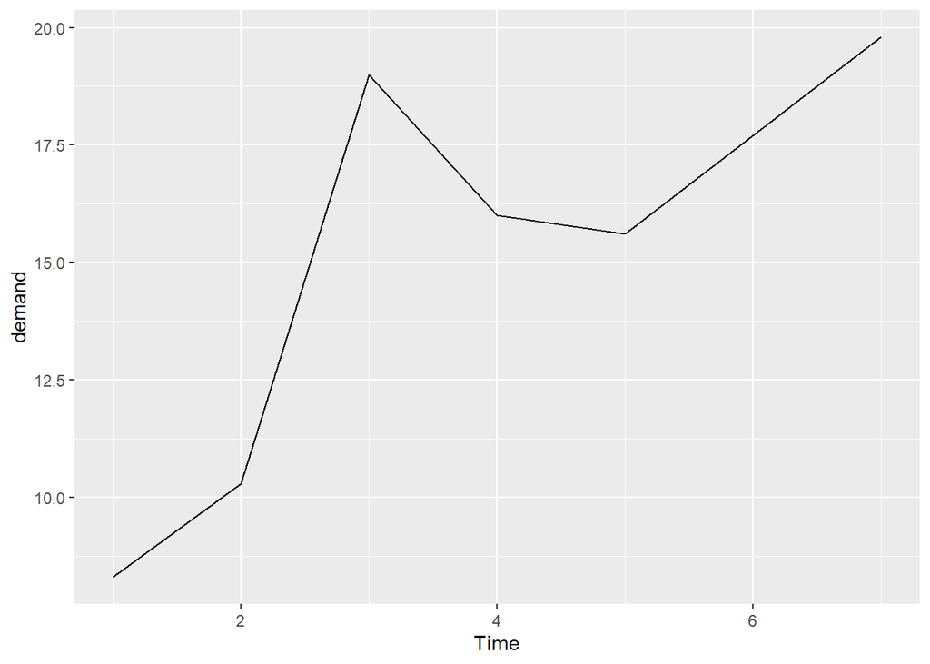

```r
ggplot(BOD, aes(x = Time, y = demand)) +
  geom_line()
```

In this part of chart, `aes(x = Time, y = demand)` specifies the aesthetics:

- `x = Time`: Assign the `Time` variable to the x-axis.
- `y = demand`: Assign the `demand variable to the y-axis (numerical data).

`geom_line`:

- Adds a line geometry to the plot.
- `geom_line` creates lines that connect data points over a continuous variable.

```r
labs(title = 'Line Chart',
       caption = 'By Daven, DV, THU, 2024') +
  theme(plot.title = element_text(hjust = 0.5, size = 20))
```

To add more details on your chart, we can add `labs()` and `theme()` into our codes.

`labs()`:

- Used to customized axis labels and legend titles.
- To add `title` and `caption` unto the chart.

`theme()`:

- Used to give plots a consistent customized look.
- Positioning your chart `title` and adjusting the `size` of your chart font.

```r
labs(title = 'Line Chart',
       caption = 'By Daven, DV, THU, 2024')
```

Inside `labs()`:

- `title = 'Line Chart'`: To add “Line Chart” as the `title`.
- `caption = 'By Daven, DV, THU, 2024'`: To add “By Daven, DV, THU, 2024” as the `caption`.

```r
theme(plot.title = element_text(hjust = 0.5, size = 20))
```

Inside `theme()`:

- `plot.title = element_text()`: To customize the `title` chart to your desire output.

Inside `plot.title = element_text()`:

- `hjust = 0.5`: Positioning your chart `title` in the middle.
- `size = 20`: Sizing your title text to `size` 20.

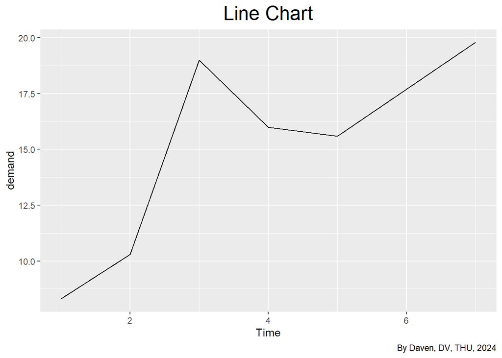

```r
library(gcookbook)
library(ggplot2)

ggplot(BOD, aes(x = Time, y = demand)) +
  geom_line() +
  labs(title = 'Line Chart',
       caption = 'By Daven, DV, THU, 2024') +
  theme(plot.title = element_text(hjust = 0.5, size = 20))
```

For a better view of the overall explanation above, this is the complete structure on how the codes *given above* should be arranged.

*Note: You can use different size of your chart title and positioning `(hjust = 1, size = 15)`.*

## 6 Histogram

In this part we’ll be drawing the `diamonds` dataset as a histogram chart.

```r
library(ggplot2)
```

```r
diamonds
```

```
# A tibble: 53,940 × 10
   carat cut       color clarity depth table price     x     y     z
   <dbl> <ord>     <ord> <ord>   <dbl> <dbl> <int> <dbl> <dbl> <dbl>
 1  0.23 Ideal     E     SI2      61.5    55   326  3.95  3.98  2.43
 2  0.21 Premium   E     SI1      59.8    61   326  3.89  3.84  2.31
 3  0.23 Good      E     VS1      56.9    65   327  4.05  4.07  2.31
 4  0.29 Premium   I     VS2      62.4    58   334  4.2   4.23  2.63
 5  0.31 Good      J     SI2      63.3    58   335  4.34  4.35  2.75
 6  0.24 Very Good J     VVS2     62.8    57   336  3.94  3.96  2.48
 7  0.24 Very Good I     VVS1     62.3    57   336  3.95  3.98  2.47
 8  0.26 Very Good H     SI1      61.9    55   337  4.07  4.11  2.53
 9  0.22 Fair      E     VS2      65.1    61   337  3.87  3.78  2.49
10  0.23 Very Good H     VS1      59.4    61   338  4     4.05  2.39
# ℹ 53,930 more rows
```

A quick preview of the `diamonds` dataset.

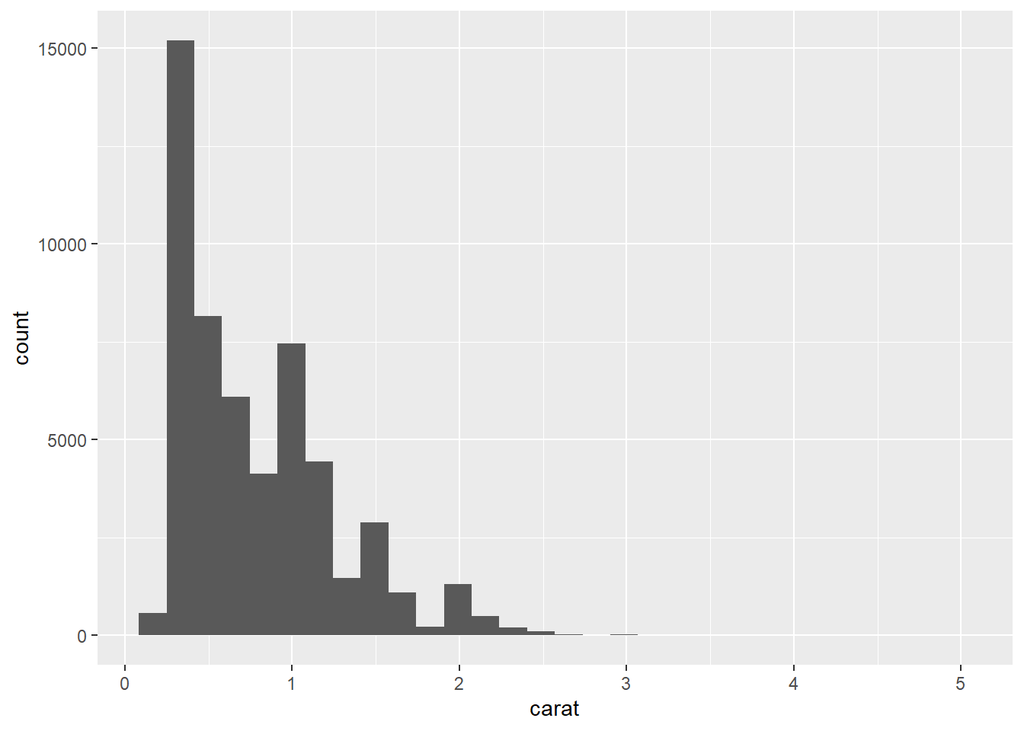

```r
ggplot(diamonds, aes (x = carat)) +
  geom_histogram()
```

in this part of chart, `aes (x = carat)` specifies the aesthetics:

- `x = carat`: Assign the `carat` variable to the x-axis.

`geom_histogram()`:

- Adds a frequency of column geometry similar to a bar to the plot.
- `geom_histogram()` visualizes the distribution of a continuous variable by dividing it into bins.

```r
labs(title = 'Histogram Chart',
       caption = 'By Daven, DV, THU') +
  theme(plot.title = element_text(hjust = 0.5, size = 20))
```

To add more details on your chart, we can add `labs()` and `theme()` into our codes.

`labs()`:

- Used to customized axis labels and legend titles.
- To add `title` and `caption` unto the chart.

`theme()`:

- Used to give plots a consistent customized look.
- Positioning your chart `title` and adjusting the `size` of your chart font.

```r
labs(title = 'Histogram Chart',
       caption = 'By Daven, DV, THU')
```

```r
theme(plot.title = element_text(hjust = 0.5, size = 20))
```

Inside `theme()`:

- `plot.title = element_text()`: To customize the `title` chart to your desire output.

Inside `plot.title = element_text()`:

- `hjust = 0.5`: Positioning your chart `title` in the middle.
- `size = 20`: Sizing your title text to `size` 20.

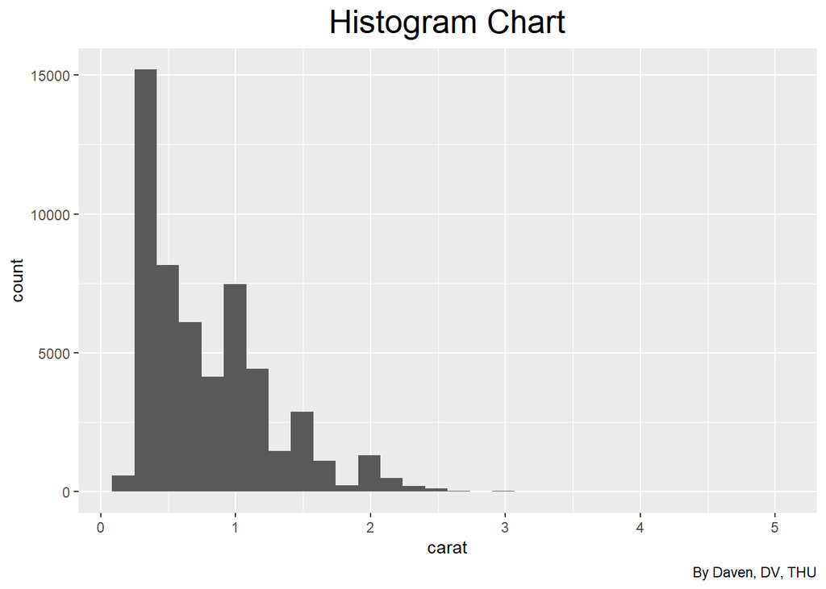

```r
library(ggplot2)

ggplot(diamonds, aes (x = carat)) +
  geom_histogram() +
  labs(title = 'Histogram Chart',
       caption = 'By Daven, DV, THU') +
  theme(plot.title = element_text(hjust = 0.5, size = 20))
```

For a better view of the overall explanation above, this is the complete structure on how the codes *given above* should be arranged.

*Note: You can use different size of your chart title and positioning `(hjust = 1, size = 15)`.*

## 7 Correlation chart

In this part, we’re going to make correlation/scatter chart using `heightweight` dataset.

```r
library(gcookbook)
library(ggplot2)
```

Here we need to initialize the `heighweight` dataset using `gcookbook` library.

```r
heightweight
```

```
    sex ageYear ageMonth heightIn weightLb
1     f   11.92      143     56.3     85.0
2     f   12.92      155     62.3    105.0
3     f   12.75      153     63.3    108.0
4     f   13.42      161     59.0     92.0
5     f   15.92      191     62.5    112.5
6     f   14.25      171     62.5    112.0
7     f   15.42      185     59.0    104.0
8     f   11.83      142     56.5     69.0
9     f   13.33      160     62.0     94.5
10    f   11.67      140     53.8     68.5
11    f   11.58      139     61.5    104.0
12    f   14.83      178     61.5    103.5
13    f   13.08      157     64.5    123.5
14    f   12.42      149     58.3     93.0
```

[output cut: 222 more lines]

A quick preview of `heightweight` dataset.

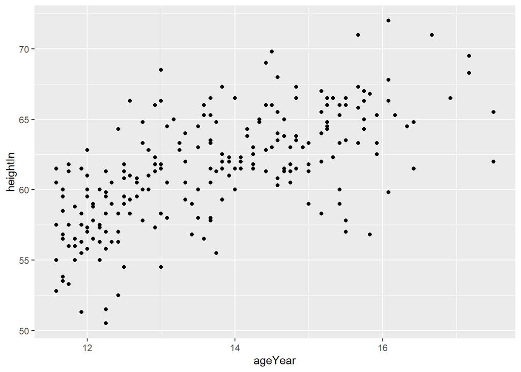

```r
ggplot(heightweight, aes(x = ageYear, y = heightIn)) +
  geom_point()
```

In this part of chart, `aes(x = ageYear, y = heightIn` specifies the aesthetics:

- `x = ageYear`: Assign `ageYear` as the x-axis label.
- `y = heightIn`: Assign `heightIn`as the y-axis label.

`geom_point()`:

- Adds multiple dots to the plots.
- `geom_point()` adds a layer of points to your plot, which creates a scatterplot.

```r
labs(title = "Age and Height",
     x = 'Age (Year)',
     y = 'Height (Inch)',
     caption = 'By Daven, DV, THU, 2024') +
  theme(plot.title = element_text(hjust = 0.5, size = 20))
```

To add more details on your chart, we can add `labs()` and `theme()` into our codes.

`labs()`:

- Used to customized axis labels and legend titles.
- To add `title` and `caption` unto the chart.

`theme()`:

- Used to give plots a consistent customized look.
- Positioning your chart `title` and adjusting the `size` of your chart font.

```r
labs(title = "Age and Height",
     x = 'Age (Year)',
     y = 'Height (Inch)',
     caption = 'By Daven, DV, THU, 2024')
```

```r
theme(plot.title = element_text(hjust = 0.5, size = 20))
```

Inside `theme()`:

- `plot.title = element_text()`: To customize the `title` chart to your desire output.

Inside `plot.title = element_text()`:

- `hjust = 0.5`: Positioning your chart `title` in the middle.
- `size = 20`: Sizing your title text to `size` 20.

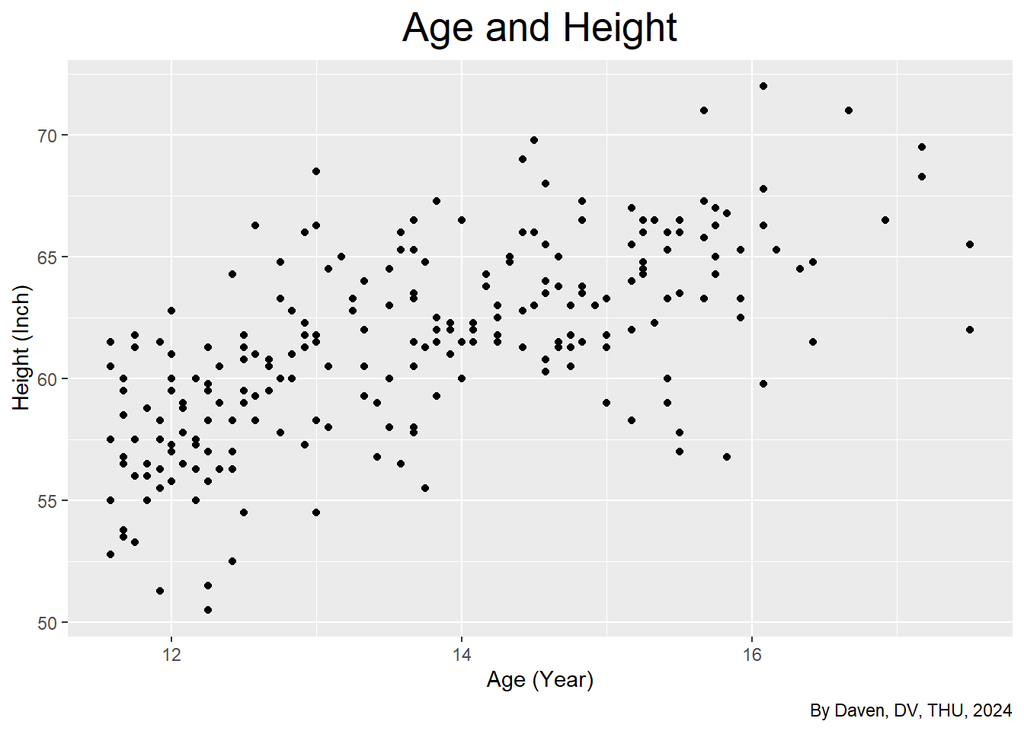

```r
library(gcookbook)
library(ggplot2)

ggplot(heightweight, aes(x = ageYear, y = heightIn)) +
  geom_point() +
  labs(title = "Age and Height",
       x = 'Age (Year)',
       y = 'Height (Inch)',
       caption = 'By Daven, DV, THU, 2024') +
  theme(plot.title = element_text(hjust = 0.5, size = 20))
```

For a better view of the overall explanation above, this is the complete structure on how the codes *given above* should be arranged.

*Note: You can use different size of your chart title and positioning `(hjust = 1, size = 15)`.*

## 8 Correlation chart: Color by group

```r
library(gcookbook)
library(ggplot2)
```

Here we need to initialize the `heighweight` dataset using `gcookbook` library.

```r
heightweight
```

```
    sex ageYear ageMonth heightIn weightLb
1     f   11.92      143     56.3     85.0
2     f   12.92      155     62.3    105.0
3     f   12.75      153     63.3    108.0
4     f   13.42      161     59.0     92.0
5     f   15.92      191     62.5    112.5
6     f   14.25      171     62.5    112.0
7     f   15.42      185     59.0    104.0
8     f   11.83      142     56.5     69.0
9     f   13.33      160     62.0     94.5
10    f   11.67      140     53.8     68.5
11    f   11.58      139     61.5    104.0
12    f   14.83      178     61.5    103.5
13    f   13.08      157     64.5    123.5
14    f   12.42      149     58.3     93.0
```

[output cut: 222 more lines]

A quick preview of `heightweight` dataset.

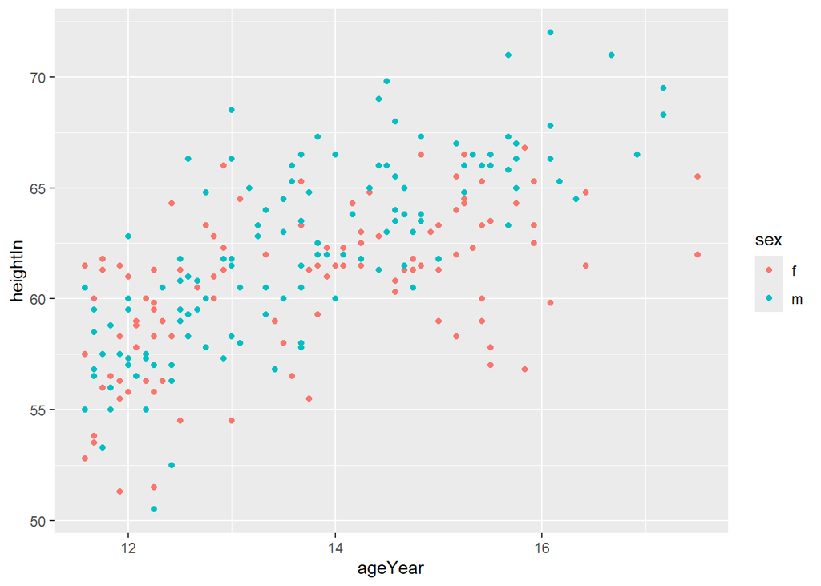

```r
ggplot(heightweight, aes(x = ageYear, y = heightIn, color = sex)) +
  geom_point()
```

In this part of chart, `aes(x = ageYear, y = heightIn, color = sex)` specifies the aesthetics:

- `x = ageYear`: Assign `ageYear` as the x-axis label.
- `y = heightIn`: Assign `heightIn`as the y-axis label.
- `color = sex`: Assign `color` to `sex` (male, female).

`geom_point()`:

- Adds multiple dots to the plots.
- `geom_point()` adds a layer of points to your plot, which creates a scatterplot.

```r
labs(title = "Age and Height by Gender",
       x = 'Age (Year)',
       y = 'Height (Inch)',
       caption = 'By Daven, DV, THU, 2024') +
  theme(plot.title = element_text(hjust = 0.5, size = 20))
```

To add more details on your chart, we can add `labs()` and `theme()` into our codes.

`labs()`:

- Used to customized axis labels and legend titles.
- To add `title` and `caption` unto the chart.

`theme()`:

- Used to give plots a consistent customized look.
- Positioning your chart `title` and adjusting the `size` of your chart font.

```r
labs(title = "Age and Height by Gender",
       x = 'Age (Year)',
       y = 'Height (Inch)',
       caption = 'By Daven, DV, THU, 2024')
```

```r
theme(plot.title = element_text(hjust = 0.5, size = 20))
```

Inside `theme()`:

- `plot.title = element_text()`: To customize the `title` chart to your desire output.

Inside `plot.title = element_text()`:

- `hjust = 0.5`: Positioning your chart `title` in the middle.
- `size = 20`: Sizing your title text to `size` 20.

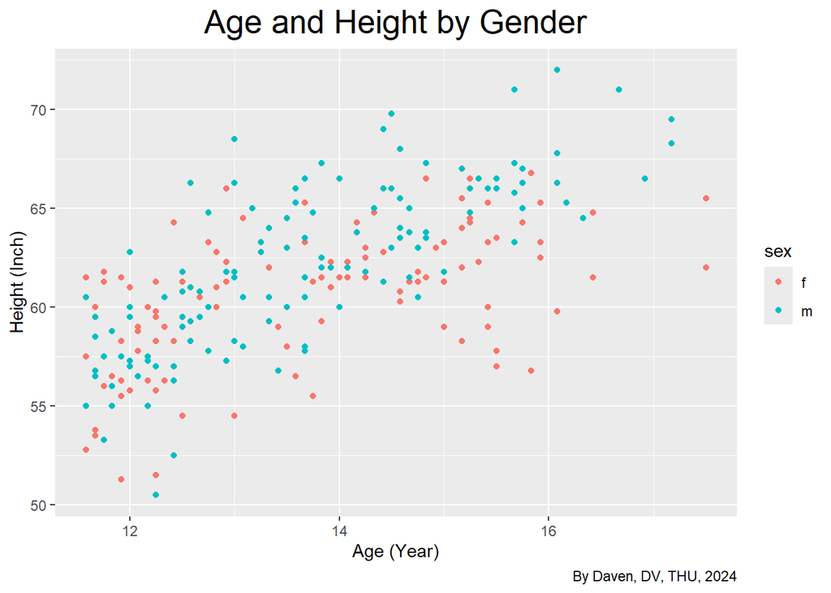

```r
library(gcookbook)
library(ggplot2)

ggplot(heightweight, aes(x = ageYear, y = heightIn, color = sex)) +
  geom_point() +
  labs(title = "Age and Height by Gender",
       x = 'Age (Year)',
       y = 'Height (Inch)',
       caption = 'By Daven, DV, THU, 2024') +
  theme(plot.title = element_text(hjust = 0.5, size = 20))
```

For a better view of the overall explanation above, this is the complete structure on how the codes *given above* should be arranged.

*Note: You can use different size of your chart title and positioning `(hjust = 1, size = 15)`.*

## 9 Multigroup histogram

Similar to Histogram, in this part we’ll be combining 2 different `group` into 1 singular chart.

```r
library(ggplot2)
library(MASS)
library(tidyverse)
```

Here, we need to initialize the `birthwt` dataset by using the `MASS` library and `tidyverse` library to combine the 2 separate chart into 1 chart.

```r
birthwt
```

```
    low age lwt race smoke ptl ht ui ftv  bwt
85    0  19 182    2     0   0  0  1   0 2523
86    0  33 155    3     0   0  0  0   3 2551
87    0  20 105    1     1   0  0  0   1 2557
88    0  21 108    1     1   0  0  1   2 2594
89    0  18 107    1     1   0  0  1   0 2600
91    0  21 124    3     0   0  0  0   0 2622
92    0  22 118    1     0   0  0  0   1 2637
93    0  17 103    3     0   0  0  0   1 2637
94    0  29 123    1     1   0  0  0   1 2663
95    0  26 113    1     1   0  0  0   0 2665
96    0  19  95    3     0   0  0  0   0 2722
97    0  19 150    3     0   0  0  0   1 2733
98    0  22  95    3     0   0  1  0   0 2751
99    0  30 107    3     0   1  0  1   2 2750
```

[output cut: 175 more lines]

A quick preview of the `birthwt` dataset.

```r
birthwt_mod <- birthwt

birthwt_mod$smoke <- recode_factor(birthwt_mod$smoke,
                                   '0' = 'No Smoke', '1' = 'Smoke')
```

Before proceeding we need to make another copy the dataset make some modification into it.

`birthwt_mod <- birthwt`:

- This to make a copy of the original dataset, so any modification will go to `birthwt_mod`.

`recode_factor`:

- Converts or modifies the `smoke` variable to a factor (categorical variable).
- Making the values are interpreted as categories instead of numeric.

`birthwt_mod$smoke, '0' = 'No Smoke', '1' = 'Smoke'`:

- Values in `smoke` that are `0` are replaced with the label `'No Smoke'`.
- Values in `smoke` that are `1` are replaced with the label `'Smoke'`.

```r
ggplot(birthwt_mod, aes(x = bwt, fill = smoke)) +
  geom_histogram(position = "identity", alpha = 0.4)
```

In this part of chart, `birthwt_mod, aes(x = bwt, fill = smoke)` specifies the aesthetics:

- `x = bwt`: Assign `bwt` variable to the x-axis.
- `fill = smoke`: Assign color based on the `smoke` variable (‘No Smoke’ and ‘Smoke’).

`geom_histogram`:

- Adds a frequency of column geometry similar to a bar to the plot.
- `geom_histogram()` visualizes the distribution of a continuous variable by dividing it into bins.

`position = "identity", alpha = 0.4`:

- `position = "identity"`: Overlays the bars for both groups (‘No Smoke’ and ‘Smoke’).
- `alpha = 0.4`: Sets the transparency level for the bars to `0.4`

```r
labs(title = "Birth Weight",
       x = 'Birth Weight',
       y = 'Count',
       caption = 'By By Daven, DV, THU, 2024') +
  theme(plot.title = element_text(hjust = 0.5, size = 20))
```

To add more details on your chart, we can add `labs()` and `theme()` into our codes.

`labs()`:

- Used to customized axis labels and legend titles.
- To add `title` and `caption` unto the chart.

`theme()`:

- Used to give plots a consistent customized look.
- Positioning your chart `title` and adjusting the `size` of your chart font.

```r
labs(title = "Birth Weight",
       x = 'Birth Weight',
       y = 'Count',
       caption = 'By By Daven, DV, THU, 2024')
```

Inside `labs()`:

- `title = 'Birth Weight'`: To add “Birth Weight” as the `title`.
- `x = 'Birth Weight'`: Assign `'Birth Weight'` as the x-axis label.
- `y = 'Count'`: Assign `'Count'` as the y-axis label.
- `caption = 'By Daven, DV, THU, 2024'`: To add “By Daven, DV, THU, 2024” as the `caption`.

```r
theme(plot.title = element_text(hjust = 0.5, size = 20))
```

Inside `theme()`:

- `plot.title = element_text()`: To customize the `title` chart to your desire output.

Inside `plot.title = element_text()`:

- `hjust = 0.5`: Positioning your chart `title` in the middle.
- `size = 20`: Sizing your title text to `size` 20.

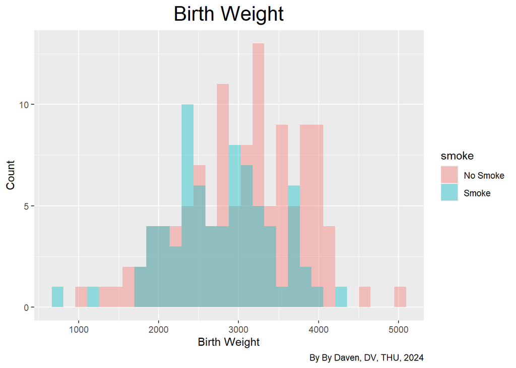

```r
library(ggplot2)
library(MASS)
library(tidyverse)

birthwt_mod <- birthwt

birthwt_mod$smoke <- recode_factor(birthwt_mod$smoke,
                                   '0' = 'No Smoke', '1' = 'Smoke')

ggplot(birthwt_mod, aes(x = bwt, fill = smoke)) +
  geom_histogram(position = "identity", alpha = 0.4) +
  labs(title = "Birth Weight",
       x = 'Birth Weight',
       y = 'Count',
       caption = 'By By Daven, DV, THU, 2024') +
  theme(plot.title = element_text(hjust = 0.5, size = 20))
```

For a better view of the overall explanation above, this is the complete structure on how the codes *given above* should be arranged.

*Note: You can use different size of your chart title and positioning `(hjust = 1, size = 15)`.*

## 10 Density chart

In this section, will be plotting a density chart using `faithful` dataset.

```r
library(ggplot2)
library(tidyr)
```

To start, we’ll need to use the `tidyr` library to use the `faithful` dataset.

```r
faithful
```

```
    eruptions waiting
1       3.600      79
2       1.800      54
3       3.333      74
4       2.283      62
5       4.533      85
6       2.883      55
7       4.700      88
8       3.600      85
9       1.950      51
10      4.350      85
11      1.833      54
12      3.917      84
13      4.200      78
14      1.750      47
```

[output cut: 258 more lines]

A quick preview of `faithful` dataset.

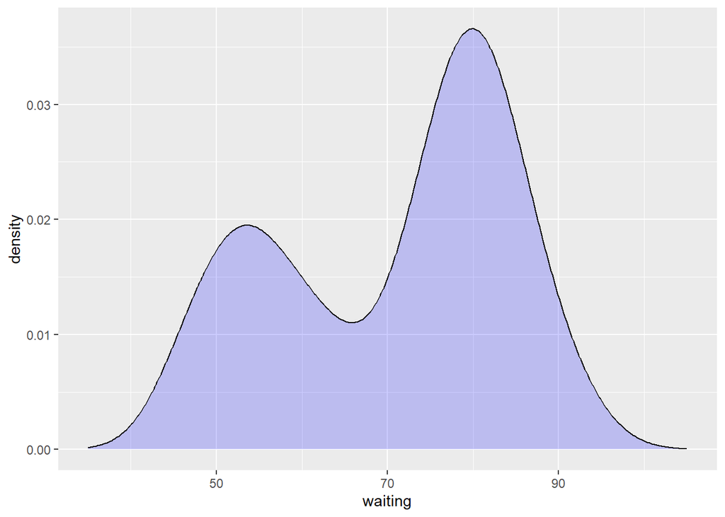

```r
ggplot(faithful, aes(x = waiting, y = ..density..)) +
  geom_density(fill = "blue", alpha = .2) +
  xlim(35, 105)
```

In this part of chart, `aes(x = waiting, y = ..density..)` specifies the aesthetics:

- `x = waiting`: Assign `waiting` variable to the x-axis.
- `y = ..density..`: Assign `..density..` variable to the y-axis. (`..density..` a special variable computed by `geom_density()`).

`geom_density`:

- Adds a density plot layer.
- `geom_density` creates smooth continuous variable version of the histogram plot.

Inside `geom_density` command, `fill = "blue", alpha = .2` specifies the following:

- `fill = "blue"`: Assign color to the bar’s area using the color `"blue"`.
- `alpha = .2`: Sets the transparency level for the bars to `.2`.

`xlim(35, 105)`:

- Sets the limits of the x-axis to the range `(35, 105)`.
- Values outside this range are excluded from the plot.

```r
abs(title = "Density Chart",
       x = 'Waiting',
       y = 'Density',
       caption = 'By By Daven, DV, THU, 2024') +
  theme(plot.title = element_text(hjust = 0.5, size = 20))
```

To add more details on your chart, we can add `labs()` and `theme()` into our codes.

`labs()`:

- Used to customized axis labels and legend titles.
- To add `title` and `caption` unto the chart.

`theme()`:

- Used to give plots a consistent customized look.
- Positioning your chart `title` and adjusting the `size` of your chart font.

```r
labs(title = 'Density Chart',
       x = 'Waiting',
       y = 'Density',
       caption = 'By By Daven, DV, THU, 2024')
```

Inside `labs()`:

- `title = 'Density Chart'`: To add “Density Chart” as the `title`.
- `x = 'Waiting'`: Assign `'Waiting'` as the x-axis label.
- `y = 'Density'`: Assign `'Density'` as the y-axis label.
- `caption = 'By Daven, DV, THU, 2024'`: To add “By Daven, DV, THU, 2024” as the `caption`.

```r
theme(plot.title = element_text(hjust = 0.5, size = 20))
```

Inside `theme()`:

- `plot.title = element_text()`: To customize the `title` chart to your desire output.

Inside `plot.title = element_text()`:

- `hjust = 0.5`: Positioning your chart `title` in the middle.
- `size = 20`: Sizing your title text to `size` 20.

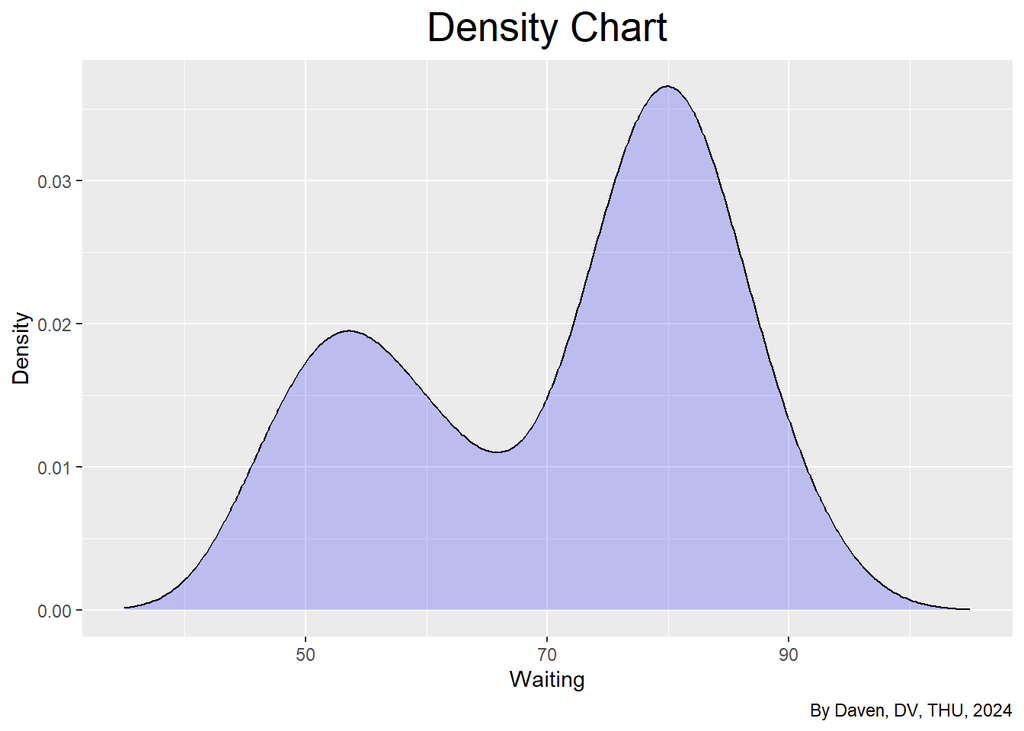

```r
library(ggplot2)
library(tidyr)

ggplot(faithful, aes(x = waiting, y = ..density..)) +
  geom_density(fill = "blue", alpha = .2) +
  xlim(35, 105) +
  labs(title = "Density Chart",
       x = 'Waiting',
       y = 'Density',
       caption = 'By Daven, DV, THU, 2024') +
  theme(plot.title = element_text(hjust = 0.5, size = 20))
```

For a better view of the overall explanation above, this is the complete structure on how the codes *given above* should be arranged.

*Note: You can use different colors on chart’s curve like `'red'` or `'green'` as well as the size of your chart title and positioning `(hjust = 1, size = 15)`.*

## 11 Box plot

Our last section, will be plotting `ToothGrowth` dataset using a boxplot chart.

```r
library(gcookbook)
library(ggplot2)
```

Here we need to initializes `ToothGrowth` dataset by using `gcookbook()` library within our code.

```r
ToothGrowth
```

```
    len supp dose
1   4.2   VC  0.5
2  11.5   VC  0.5
3   7.3   VC  0.5
4   5.8   VC  0.5
5   6.4   VC  0.5
6  10.0   VC  0.5
7  11.2   VC  0.5
8  11.2   VC  0.5
9   5.2   VC  0.5
10  7.0   VC  0.5
11 16.5   VC  1.0
12 16.5   VC  1.0
13 15.2   VC  1.0
14 17.3   VC  1.0
```

[output cut: 46 more lines]

A quick preview of `ToothGrowth` dataset.

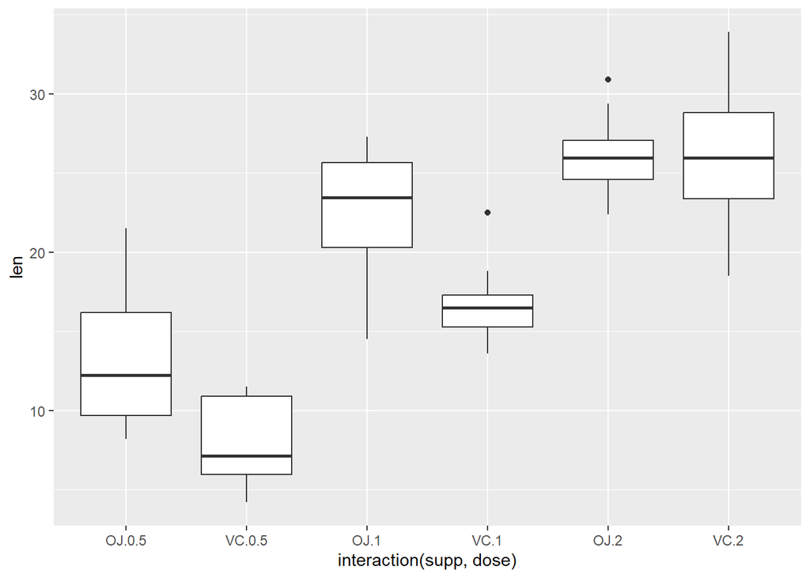

```r
ggplot(ToothGrowth, aes(x = interaction(supp, dose), y = len)) +
  geom_boxplot()
```

In this part of chart, `aes(x = interaction(supp, dose), y = len)` specifies the aesthetics:

- `x = interaction(supp, dose)`: Assign `interaction(supp, dose)` variable to the x-axis label by combining levels of `supp` (VC or OJ) and `dose` (0.5, 1, or 2).
- `y = len`: Assign `len` variable to the y-axis.

`geom_boxplot()`:

- Adds a boxplot layer to the plot.
- `geom_boxplot` summarizes the distribution of `len` for each group defined by the interaction of `supp` and `dose`.

```r
labs(title = "Boxplot with ggplot",
       x = 'Supp + Dose',
       y = 'Length',
       fill = "Smoking Status",
       caption = 'By Daven, DV, THU, 2024') +
  theme(plot.title = element_text(hjust = 0.5, size = 20))
```

To add more details on your chart, we can add `labs()` and `theme()` into our codes.

`labs()`:

- Used to customized axis labels and legend titles.
- To add `title` and `caption` unto the chart.

`theme()`:

- Used to give plots a consistent customized look.
- Positioning your chart `title` and adjusting the `size` of your chart font.

```r
labs(title = 'Boxplot with ggplot',
       x = 'Supp + Dose',
       y = 'Length',
       fill = 'Smoking Status',
       caption = 'By Daven, DV, THU, 2024')
```

Inside `labs()`:

- `title = 'Boxplot with ggplot'`: To add “Boxplot with ggplot” as the `title`.
- `x = 'Supp + Dose'`: Assign `'Supp + Dose'` as the x-axis label.
- `y = 'Length'`: Assign `'Length'` as the y-axis label.
- `fill = 'Smoking Status'`: Assign the legend `title` for the `fill` to `'Smoking Status'`.
- `caption = 'By Daven, DV, THU, 2024'`: To add “By Daven, DV, THU, 2024” as the `caption`.

```r
theme(plot.title = element_text(hjust = 0.5, size = 20))
```

Inside `theme()`:

- `plot.title = element_text()`: To customize the `title` chart to your desire output.

Inside `plot.title = element_text()`:

- `hjust = 0.5`: Positioning your chart `title` in the middle.
- `size = 20`: Sizing your title text to `size` 20.

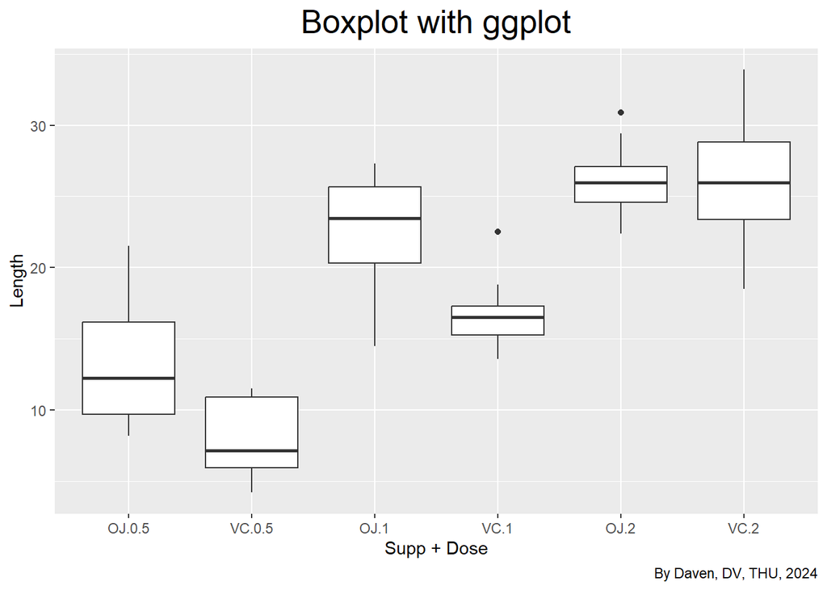

```r
library(gcookbook)
library(ggplot2)

ggplot(ToothGrowth, aes(x = interaction(supp, dose), y = len)) +
  geom_boxplot() +
  labs(title = "Boxplot with ggplot",
       x = 'Supp + Dose',
       y = 'Length',
       fill = "Smoking Status",
       caption = 'By Daven, DV, THU, 2024') +
  theme(plot.title = element_text(hjust = 0.5, size = 20))
```

For a better view of the overall explanation above, this is the complete structure on how the codes *given above* should be arranged.

*Note: You can use different size of your chart title and positioning `(hjust = 1, size = 15)`.*